# Project: Investigate TMDb movie data set

- Introduction
- Data Wrangling
- Exploratory Data Analysis
- Conclusions

## Introduction

The objective of the project is to go through the dataset and the general data analysis process using numpy, pandas and matplotlib. I selected the movies data set from Kaggle. The dataset consists of 10,000 movies which contains information about budget, ratings, revenue,..etc.

The explored questions are:

### - Q1: What are the top 10 production companies that release movies?

### - Q2: In which decade was the profits the highest?

### - Q3: What is the common average runtime? And how does it affect the budget?

### - Q4: What are the most productive genres of movies?

### - Q5: What is the distribution of movies released over the years?

```python
# Import statements for all of the packages that I will need.

import pandas as pd
import numpy as np
import matplotlib.pyplot as plt
import seaborn as sns
%matplotlib inline
```

## Data Wrangling

> In this step we will be keeping only the necessary data and deleting the unused data so that we can make our calculation easy and clear.

### General Properties

```python
# Loading the data :
#Use pd.read_csv to load the movie dataset.

md = pd.read_csv('moviesdata11.csv')

#printing first five rows with defined columns of tmdb-movies database
md.head()
```

|  | id | imdb_id | popularity | budget | revenue | original_title | cast | homepage | director | tagline | ... | overview | runtime | genres | production_companies | release_date | vote_count | vote_average | release_year | budget_adj | revenue_adj |
| --- | --- | --- | --- | --- | --- | --- | --- | --- | --- | --- | --- | --- | --- | --- | --- | --- | --- | --- | --- | --- | --- |
| 0 | 135397 | tt0369610 | 32.985763 | 150000000 | 1513528810 | Jurassic World | Chris Pratt\|Bryce Dallas Howard\|Irrfan Khan\|Vi... | http://www.jurassicworld.com/ | Colin Trevorrow | The park is open. | ... | Twenty-two years after the events of Jurassic ... | 124 | Action\|Adventure\|Science Fiction\|Thriller | Universal Studios\|Amblin Entertainment\|Legenda... | 6/9/15 | 5562 | 6.5 | 2015 | 1.379999e+08 | 1.392446e+09 |
| 1 | 76341 | tt1392190 | 28.419936 | 150000000 | 378436354 | Mad Max: Fury Road | Tom Hardy\|Charlize Theron\|Hugh Keays-Byrne\|Nic... | http://www.madmaxmovie.com/ | George Miller | What a Lovely Day. | ... | An apocalyptic story set in the furthest reach... | 120 | Action\|Adventure\|Science Fiction\|Thriller | Village Roadshow Pictures\|Kennedy Miller Produ... | 5/13/15 | 6185 | 7.1 | 2015 | 1.379999e+08 | 3.481613e+08 |
| 2 | 262500 | tt2908446 | 13.112507 | 110000000 | 295238201 | Insurgent | Shailene Woodley\|Theo James\|Kate Winslet\|Ansel... | http://www.thedivergentseries.movie/#insurgent | Robert Schwentke | One Choice Can Destroy You | ... | Beatrice Prior must confront her inner demons ... | 119 | Adventure\|Science Fiction\|Thriller | Summit Entertainment\|Mandeville Films\|Red Wago... | 3/18/15 | 2480 | 6.3 | 2015 | 1.012000e+08 | 2.716190e+08 |
| 3 | 140607 | tt2488496 | 11.173104 | 200000000 | 2068178225 | Star Wars: The Force Awakens | Harrison Ford\|Mark Hamill\|Carrie Fisher\|Adam D... | http://www.starwars.com/films/star-wars-episod... | J.J. Abrams | Every generation has a story. | ... | Thirty years after defeating the Galactic Empi... | 136 | Action\|Adventure\|Science Fiction\|Fantasy | Lucasfilm\|Truenorth Productions\|Bad Robot | 12/15/15 | 5292 | 7.5 | 2015 | 1.839999e+08 | 1.902723e+09 |
| 4 | 168259 | tt2820852 | 9.335014 | 190000000 | 1506249360 | Furious 7 | Vin Diesel\|Paul Walker\|Jason Statham\|Michelle ... | http://www.furious7.com/ | James Wan | Vengeance Hits Home | ... | Deckard Shaw seeks revenge against Dominic Tor... | 137 | Action\|Crime\|Thriller | Universal Pictures\|Original Film\|Media Rights ... | 4/1/15 | 2947 | 7.3 | 2015 | 1.747999e+08 | 1.385749e+09 |

5 rows × 21 columns

```python
#display the data's dimensions
md.shape
```

```
(10866, 21)
```

#### To find summary of the basic information like data format, the number of null values in each column in the dataset.

```python
#display the data's info
md.info()
```

```
<class 'pandas.core.frame.DataFrame'>
RangeIndex: 10866 entries, 0 to 10865
Data columns (total 21 columns):
 #   Column                Non-Null Count  Dtype
---  ------                --------------  -----
 0   id                    10866 non-null  int64
 1   imdb_id               10856 non-null  object
 2   popularity            10866 non-null  float64
 3   budget                10866 non-null  int64
 4   revenue               10866 non-null  int64
 5   original_title        10866 non-null  object
 6   cast                  10790 non-null  object
 7   homepage              2936 non-null   object
 8   director              10822 non-null  object
 9   tagline               8042 non-null   object
 10  keywords              9373 non-null   object
 11  overview              10862 non-null  object
 12  runtime               10866 non-null  int64
 13  genres                10843 non-null  object
 14  production_companies  9836 non-null   object
 15  release_date          10866 non-null  object
 16  vote_count            10866 non-null  int64
 17  vote_average          10866 non-null  float64
 18  release_year          10866 non-null  int64
 19  budget_adj            10866 non-null  float64
 20  revenue_adj           10866 non-null  float64
dtypes: float64(4), int64(6), object(11)
memory usage: 1.7+ MB
```

#### And for general statistics about the dataframe.

```python
#display the data’s structures
md.describe()
```

|  | id | popularity | budget | revenue | runtime | vote_count | vote_average | release_year | budget_adj | revenue_adj |
| --- | --- | --- | --- | --- | --- | --- | --- | --- | --- | --- |
| count | 10866.000000 | 10866.000000 | 1.086600e+04 | 1.086600e+04 | 10866.000000 | 10866.000000 | 10866.000000 | 10866.000000 | 1.086600e+04 | 1.086600e+04 |
| mean | 66064.177434 | 0.646441 | 1.462570e+07 | 3.982332e+07 | 102.070863 | 217.389748 | 5.974922 | 2001.322658 | 1.755104e+07 | 5.136436e+07 |
| std | 92130.136561 | 1.000185 | 3.091321e+07 | 1.170035e+08 | 31.381405 | 575.619058 | 0.935142 | 12.812941 | 3.430616e+07 | 1.446325e+08 |
| min | 5.000000 | 0.000065 | 0.000000e+00 | 0.000000e+00 | 0.000000 | 10.000000 | 1.500000 | 1960.000000 | 0.000000e+00 | 0.000000e+00 |
| 25% | 10596.250000 | 0.207583 | 0.000000e+00 | 0.000000e+00 | 90.000000 | 17.000000 | 5.400000 | 1995.000000 | 0.000000e+00 | 0.000000e+00 |
| 50% | 20669.000000 | 0.383856 | 0.000000e+00 | 0.000000e+00 | 99.000000 | 38.000000 | 6.000000 | 2006.000000 | 0.000000e+00 | 0.000000e+00 |
| 75% | 75610.000000 | 0.713817 | 1.500000e+07 | 2.400000e+07 | 111.000000 | 145.750000 | 6.600000 | 2011.000000 | 2.085325e+07 | 3.369710e+07 |
| max | 417859.000000 | 32.985763 | 4.250000e+08 | 2.781506e+09 | 900.000000 | 9767.000000 | 9.200000 | 2015.000000 | 4.250000e+08 | 2.827124e+09 |

#### For visualize the data(Numerical data) by column to inspect the data:

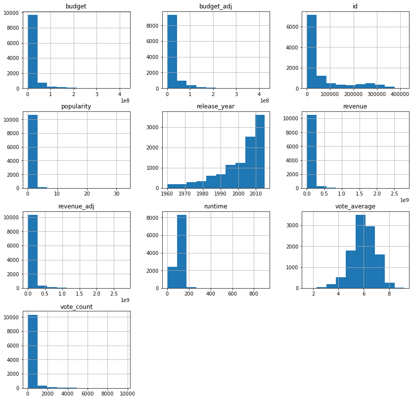

```python
md.hist(figsize = (14, 14));
```

#### As we can see, the histogram indicate that many columns, like budget and revenue, contain many "0" in their columns.

### And for catigoral data

```python
md.isnull().sum()
```

```
id                         0
imdb_id                   10
popularity                 0
budget                     0
revenue                    0
original_title             0
cast                      76
homepage                7930
director                  44
tagline                 2824
keywords                1493
overview                   4
runtime                    0
genres                    23
production_companies    1030
release_date               0
vote_count                 0
vote_average               0
release_year               0
budget_adj                 0
revenue_adj                0
dtype: int64
```

### Data Cleaning (Removing The Unused Information From The Dataset)

> The runtime, release_year, genres, budget_adj, vote_average, and production_companies columns are the main columns of information we need to answer the questions and also budjet and revenue may support our information, so we will drop the others columns that unused for our analysis.

#### we will change essential columns its "0" values into "nan" and the respective colums will be dropped for the analysis

```python
md['vote_average'].replace(0, np.NAN, inplace=True)
md['runtime'].replace(0, np.NAN, inplace=True)
md['budget'].replace(0, np.NAN, inplace=True)
md['budget_adj'].replace(0, np.NAN, inplace=True)
md['revenue'].replace(0, np.NAN, inplace=True)
md['revenue_adj'].replace(0, np.NAN, inplace=True)

md.dropna(axis=0, inplace=True)
```

#### Information on genres and production companies is missing so due to the amount of the dataset the simplest solution is to drop these films from the dataset for this analysis.

```python
md.dropna(axis = 0, inplace = True, subset = ['genres','production_companies'])
```

#### Then we will remove unnecessary columns

```python
# drop unused columns
md.drop(['id', 'imdb_id', 'popularity', 'original_title', 'cast', 'homepage','director',
         'tagline', 'keywords', 'overview', 'release_date', 'vote_count'], axis = 1, inplace = True)
```

#### Now let's check the dataset after cleannig

```python
# disply the new data's info
md.info()
```

```
<class 'pandas.core.frame.DataFrame'>
Int64Index: 1287 entries, 0 to 10760
Data columns (total 9 columns):
 #   Column                Non-Null Count  Dtype
---  ------                --------------  -----
 0   budget                1287 non-null   float64
 1   revenue               1287 non-null   float64
 2   runtime               1287 non-null   float64
 3   genres                1287 non-null   object
 4   production_companies  1287 non-null   object
 5   vote_average          1287 non-null   float64
 6   release_year          1287 non-null   int64
 7   budget_adj            1287 non-null   float64
 8   revenue_adj           1287 non-null   float64
dtypes: float64(6), int64(1), object(2)
memory usage: 100.5+ KB
```

```python
# disply the new data's dimensions
md.shape
```

```
(1287, 9)
```

```python
md.isnull().sum()
```

```
budget                  0
revenue                 0
runtime                 0
genres                  0
production_companies    0
vote_average            0
release_year            0
budget_adj              0
revenue_adj             0
dtype: int64
```

#### Now our dataset is cleaned and ready to analysing

```python
# save the cleaned data to 'cleaned_md.csv'
md.to_csv('cleaned_md.csv', index=False)
```

# Exploratory Data Analysis

> In this step we gonna Compute statistics and create visualizations with the goal of addressing the research questions that you posed in the Introduction section

## Q1: What are the top 10 production companies that release movies?

#### First, we will import the new file after cleaning

```python
md_clean = pd.read_csv('cleaned_md.csv')
md_clean.head()
```

|  | budget | revenue | runtime | genres | production_companies | vote_average | release_year | budget_adj | revenue_adj |
| --- | --- | --- | --- | --- | --- | --- | --- | --- | --- |
| 0 | 150000000.0 | 1.513529e+09 | 124.0 | Action\|Adventure\|Science Fiction\|Thriller | Universal Studios\|Amblin Entertainment\|Legenda... | 6.5 | 2015 | 1.379999e+08 | 1.392446e+09 |
| 1 | 150000000.0 | 3.784364e+08 | 120.0 | Action\|Adventure\|Science Fiction\|Thriller | Village Roadshow Pictures\|Kennedy Miller Produ... | 7.1 | 2015 | 1.379999e+08 | 3.481613e+08 |
| 2 | 110000000.0 | 2.952382e+08 | 119.0 | Adventure\|Science Fiction\|Thriller | Summit Entertainment\|Mandeville Films\|Red Wago... | 6.3 | 2015 | 1.012000e+08 | 2.716190e+08 |
| 3 | 200000000.0 | 2.068178e+09 | 136.0 | Action\|Adventure\|Science Fiction\|Fantasy | Lucasfilm\|Truenorth Productions\|Bad Robot | 7.5 | 2015 | 1.839999e+08 | 1.902723e+09 |
| 4 | 190000000.0 | 1.506249e+09 | 137.0 | Action\|Crime\|Thriller | Universal Pictures\|Original Film\|Media Rights ... | 7.3 | 2015 | 1.747999e+08 | 1.385749e+09 |

#### There are a lot of divisions in the production_companies column so we'll go for a specific definition to to split them

```python
def production_company(x):
    #To split all information in the column
    data_plot = md_clean[x].str.cat(sep = '|')
    data = pd.Series(data_plot.split('|'))
    info = data.value_counts(ascending=False)
    return info
```

#### display the first 10 rows that we need

```python
df1 = production_company('production_companies')
df1.head(10)
```

```
Universal Pictures                        120
Warner Bros.                              118
Columbia Pictures                          74
Paramount Pictures                         71
Relativity Media                           68
Walt Disney Pictures                       62
Twentieth Century Fox Film Corporation     53
New Line Cinema                            50
Village Roadshow Pictures                  38
Metro-Goldwyn-Mayer (MGM)                  32
dtype: int64
```

#### Now we are going to visualization it

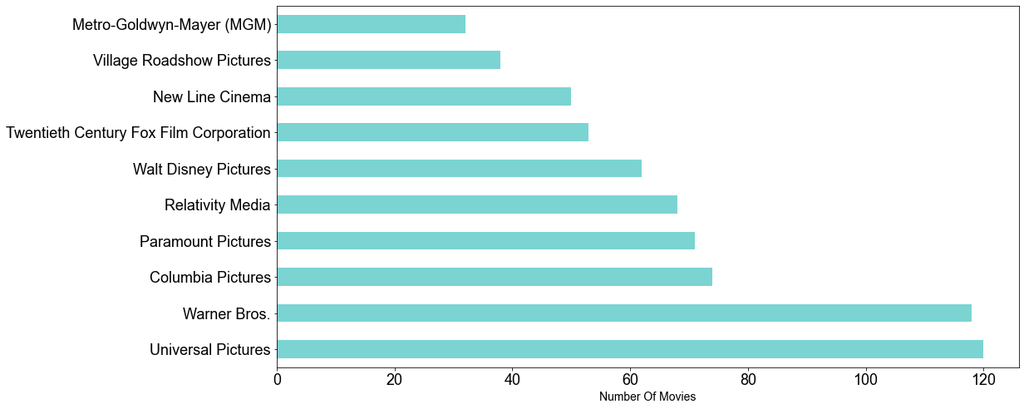

```python
production_companies = production_company('production_companies')
#plot the column.
production_companies.iloc[:10].plot(kind='barh',figsize=(16,8),fontsize=18, color= '#7bd4d2' )
plt.xlabel('Number Of Movies',fontsize=14)
sns.set_style("whitegrid")
```

#### The graphic shows the production rate of most companies releasing movies.

#### The most productive company on our dataset is Universal Pictures، about 120 movies.

#### To answer this question, we'll need to know the profit which is not included in our dataset, so to calculate profits, we do the following process, which is to subtract the budget from the revenues.

> *There is no currency shown in the dataset, so we'll assume it's in the World currency (dollar).

```python
# We'll calculate profits and add them as a new column in the dataset
md_clean.insert(2,'profit_earning',md_clean['revenue_adj']-md_clean['budget_adj'])

#display the dataset
md_clean.head()
```

|  | budget | revenue | profit_earning | runtime | genres | production_companies | vote_average | release_year | budget_adj | revenue_adj |
| --- | --- | --- | --- | --- | --- | --- | --- | --- | --- | --- |
| 0 | 150000000.0 | 1.513529e+09 | 1.254446e+09 | 124.0 | Action\|Adventure\|Science Fiction\|Thriller | Universal Studios\|Amblin Entertainment\|Legenda... | 6.5 | 2015 | 1.379999e+08 | 1.392446e+09 |
| 1 | 150000000.0 | 3.784364e+08 | 2.101614e+08 | 120.0 | Action\|Adventure\|Science Fiction\|Thriller | Village Roadshow Pictures\|Kennedy Miller Produ... | 7.1 | 2015 | 1.379999e+08 | 3.481613e+08 |
| 2 | 110000000.0 | 2.952382e+08 | 1.704191e+08 | 119.0 | Adventure\|Science Fiction\|Thriller | Summit Entertainment\|Mandeville Films\|Red Wago... | 6.3 | 2015 | 1.012000e+08 | 2.716190e+08 |
| 3 | 200000000.0 | 2.068178e+09 | 1.718723e+09 | 136.0 | Action\|Adventure\|Science Fiction\|Fantasy | Lucasfilm\|Truenorth Productions\|Bad Robot | 7.5 | 2015 | 1.839999e+08 | 1.902723e+09 |
| 4 | 190000000.0 | 1.506249e+09 | 1.210949e+09 | 137.0 | Action\|Crime\|Thriller | Universal Pictures\|Original Film\|Media Rights ... | 7.3 | 2015 | 1.747999e+08 | 1.385749e+09 |

#### As we can see now we have a new profit column.

```python
df2= pd.DataFrame(md_clean.groupby('release_year').profit_earning.sum())
df2.head()
```

| release_year | profit_earning |
| --- | --- |
| 1961 | 7.294861e+06 |
| 1962 | 4.216943e+08 |
| 1963 | 5.439729e+08 |
| 1964 | 8.569935e+08 |
| 1965 | 9.010273e+08 |

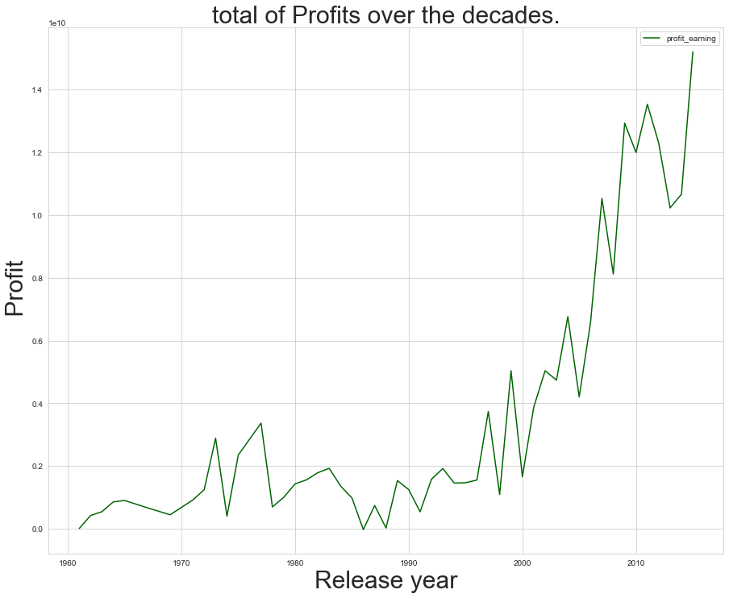

```python
df2.plot.line(color='Darkgreen',figsize=(15, 12) );

# naming the labels of the graph.
plt.title("total of Profits over the decades.",fontsize = 30);
plt.xlabel('Release year',fontsize = 30);
plt.ylabel(' Profit',fontsize = 30);
```

### Q3: What is the common average runtime? And how does it affect the budget?

### 1- The common average runtime:

```python
md_clean['runtime'].mean()
```

```
110.27350427350427
```

#### Visualize the average of runtime by box plot.

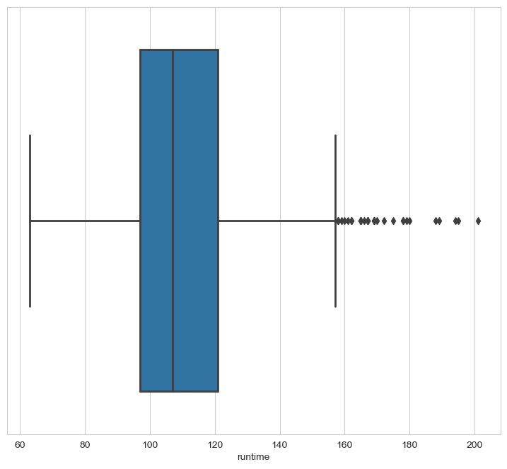

```python
plt.figure(figsize=(9,8), dpi = 100)

#plotting box plot
sns.boxplot(md_clean['runtime'], linewidth = 2 )
# display the plot
plt.show()
```

### 2- The relationship between the average runtime and the budget:

#### We will illustrate the relationship by the following diagram:

[figure not shown]

```python
# use scatter kind to clarify the distribution
md_clean.plot(x='runtime', y='budget_adj', kind='scatter' , figsize=(15,10) )
plt.title('Ratings & Runtime')
plt.xlabel('Runtime')
plt.ylabel('budget');
```

### Q4: What are the most productive genres of movies?

#### We want to know which genres of movies are most frequently in the data set, and since this column also contains alot of division , we will define the following:

```python
def geners(x):
    #to split all information in the column
    data_plot = md_clean[x].str.cat(sep = '|')
    data = pd.Series(data_plot.split('|'))
    #conts the genres and return.
    info = data.value_counts(ascending=False)
    return info
```

```python
df3= geners('genres')
#disply the genres
df3.head()
```

```
Drama        535
Action       415
Comedy       414
Thriller     399
Adventure    297
dtype: int64
```

### Now we illustrate the list of genres in the chart

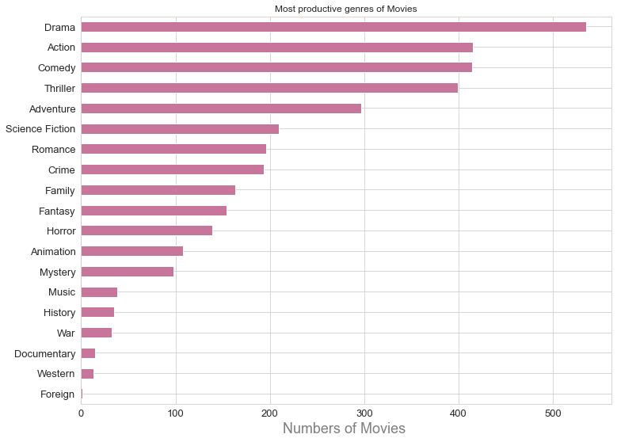

```python
df3.sort_values(ascending = True, inplace = True)

#ploting
lt = df3.plot.barh(color ='#c7759a', fontsize = 13)

#naming the title
lt.set(title = 'Most productive genres of Movies')
#designation x axis
lt.set_xlabel('Numbers of Movies ', color = 'grey', fontsize = '18')

#figure size(width, height)
lt.figure.set_size_inches(12, 9)

#display the graph
plt.show()
```

#### Drama is the most frequent genres in the dataset, about 535 movies.

### Q5: What is the distribution of movies released over the years?

#### To illustrate the distribution of the movies release over the years in the following diagram:

```python
md_clean['release_year'].value_counts()
```

```
2011    156
2010    132
2009    116
2015     93
2007     92
2012     88
2008     82
2014     70
2006     68
2013     65
2005     51
2004     43
2003     30
2002     24
1999     22
```

[output cut: 37 more lines]

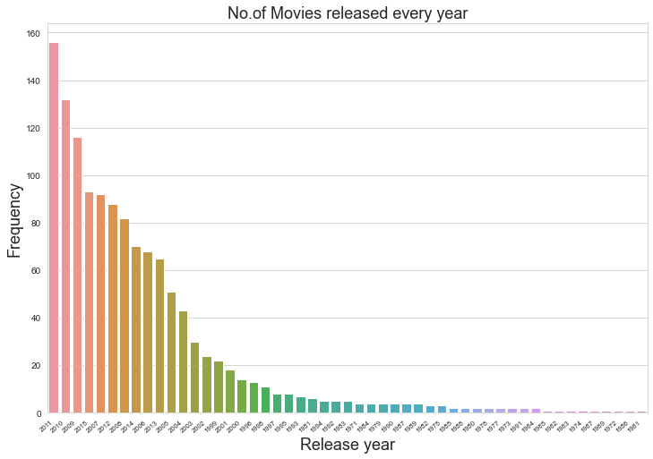

```python
plt.figure(figsize = (12,8))
#bar plot for no.movies released every year
ax=sns.countplot(x = 'release_year', data = md_clean, order = md_clean['release_year'].value_counts().index);
#Rotate xticklabels
ax.set_xticklabels(ax.get_xticklabels(),rotation = 40, ha= 'right', fontsize = 7.6);
#Give label to x-axis,y-axis & a title
plt.xlabel('Release year', fontsize = 18);
plt.ylabel('Frequency',fontsize = 18);
plt.title('No.of Movies released every year',fontsize = 18);
```

#### If we compared the rate of movies produced in the 1970s with the 2000s, we would notice that the production of movies is growing gradually and Ascending, and perhaps the modern technology that has become easier and faster than that of the 1970s is due to this, which means that the production of films is in line with this development that the world is witnessing.

### Now that we're done analyzing the data, we'll summarize the work:

#### Part one:

> - Ask questions that we will analyze and explore.
> - import the package we will needed

#### Part II:

> - load the dataset file.
> - Cleaning data in general and also in particular based on the questions posed
> - Save data after cleaning as a CSV file new.

#### Part III:

> - Explore the data and answer the questions: #### Q1: What are the top 10 production companies that release movies? The most productive company on our dataset is Universal Pictures about 120 movies.

#### Q2: In which decade were the profits the highest?

> We explained in the chart that profits increase over the years.

#### Finally, the movies industry is increasing over time, and there are a lot of factors that may affect the productivity of movies whether it is budgets, revenue or even rating and voting, and also the majority of audience prefer films that are no more than two hours so maybe even the average runtime may affect negatively or positively

### Limitations

- The dataset was to contain more than 10866 row but they have a lot of missing values in companies production, classifications, and value was zero in the budget and revenue, which made me delete this data.
- In genres and production companies columns, there were a lot of divisions between them, so I had to separate them so I could analyze them individually.
- The dataset did not contain some additional information that might be necessary, such as classifying the movies by an age group and their suitability.
- There was no specific currency in terms of revenue and budget so I assumed it was in dollars.

#### Resources

https://github.com/antra0497

https://www.kaggle.com/lorenzhering